# Effects of Age, Gender and Day of the week on Duration and Distance and how to convert customers into subscribers in Fordbike sharing

# Investigation Overview

In this investigation, I wanted to look at the characteristics of bike-sharing activities that could be used to improve their marketing strategy. The main focus was on Age, Gender, Day of the week, Duration and Distance, and how to convert customers into subscribers.

## Dataset Overview

The data consisted of data of clients that contains approximately 174952 clients. The attributes include the clients birth date, client gender, duration, locations of the ride (start and end station coordinates and start and end station ID), day of the weak of the ride, as well as additional measurements such as bike ID, user type(being a subscriber of or a customer). 8,460 data points were removed from the analysis due to inconsistencies or missing information.

# Data visulazation

### count of subscribers in comparison with customers

almost 90% of the clients are subscribers, the goal is to keep the subscribers and encourage customers to convert into subscribers

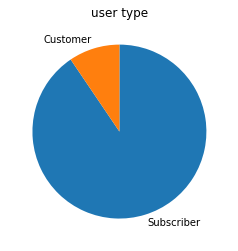

almost 75% of the clients are male, it would be an added option if the company start to introduce bikes more suitable for females to attract them, such as pink bikes, more safety measurements for females, etc

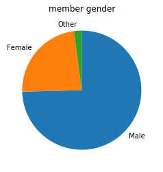

### count of each generation in the data

Most members are people between the age of 30 and 40. and the lowest in the kids between 10 and 20. my thoughts are:  
1- introduce more bikes suitable for teenagers between the age of 10-20.  
2- promotional codes for generations between the ages of 20-30 to attract them.  
3- celebrate the seniors with ages ranges between 60 and 80 and give them special offers.  
4- it would be a huge addition if the company provided their service to generations older than 80 for free. They are not a majority and it would be an excellent advertisement for the company

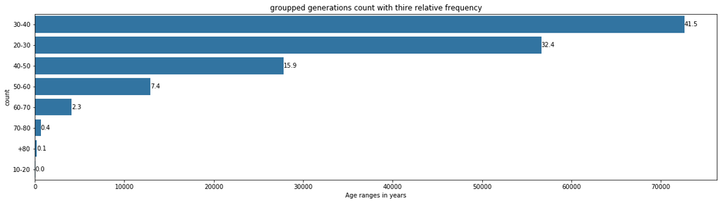

### Bike-sharing activity in each day of the week

the graph shows a decline in bike use on the weekends, we can do the following:  
1- promotion codes on the weekend.  
2- promotion codes on Monday, it seems as the start of the week and clients aren't ready yet to start their journey after the weekend

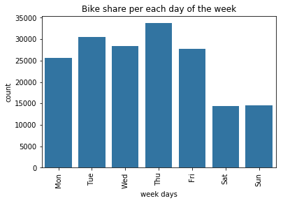

### Duration of bike-sharing per each member age

the graph shows the highest duration for individuals below 20 years old and the highest stander deviation of duration for ages below 20 and consistent average duration for ages between 20 and 120 with a slight decline in duration for ages around 80

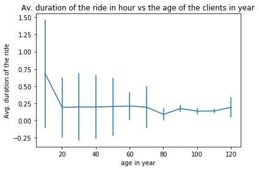

### Average ride duration for each age who take the bike and return it to the same location

The graphs show a higher ride duration and a higher percentage of customers than the full data. my opinion is as follow:  
1- The station in this data will be always busy, and bikes might not be available for subscribers especially if the member was between the age of 30 and 40. Fordbike should add more bikes to these stations to satisfy its subscribers.  
2- encourage customers with high ride duration to subscribe to their services with promotions and codes

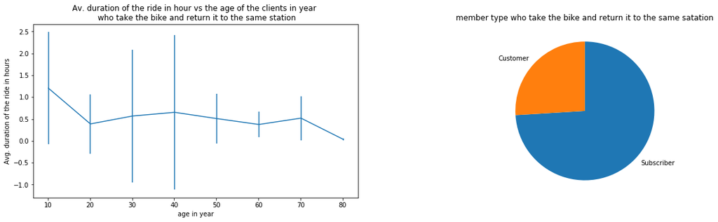

### count of each generation and with their member type

the graph shows the different distributions for the grouped generation with their user type which shows a very large difference between being a subscriber and a customer. but there is a kind of a fixed ratio between generation and being a customer or a subscriber

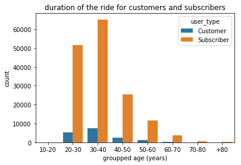

### count of member type per each day of the week

The heat map shows the count of member types through the weekdays. which shows the caount of each member in each day of the weak  
my observation were as follow:  
1- customers are usually about 10% in the working days (from Mondays to Fridays).  
2- the ratio of customers/subscribers raise to 17-18% in the weekends.  
my opinin is:  
promotion codes for customers on the weekend to encourage them to subscribe.

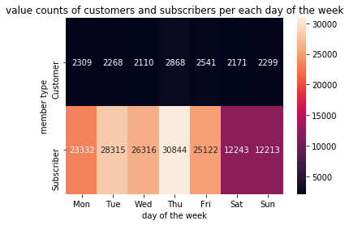

### Relation between distance and duration in respect to member type

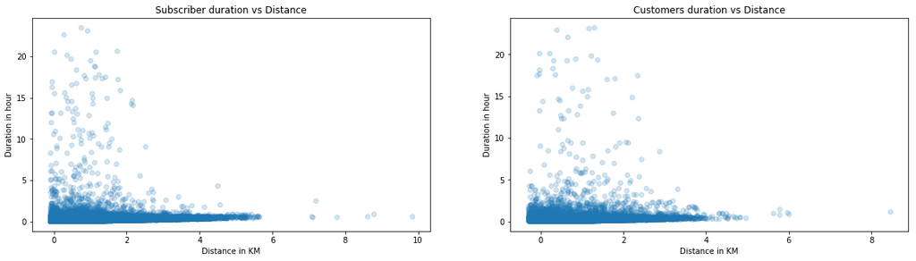

### Relation between distance and duration in respect to member type per each day of the week

This graph shows a scatter plot for duration and distance for different members type (customer VS subscribers) through the weekdays

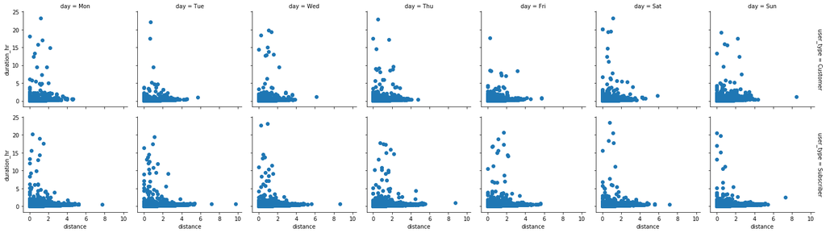

### Relation between distance and duration in respect to member gender per each day of the week

This graph shows a scatter plot for duration and distance for different gender types (male, female and other) through the weekdays which clearly shows that males used to share bikes more often

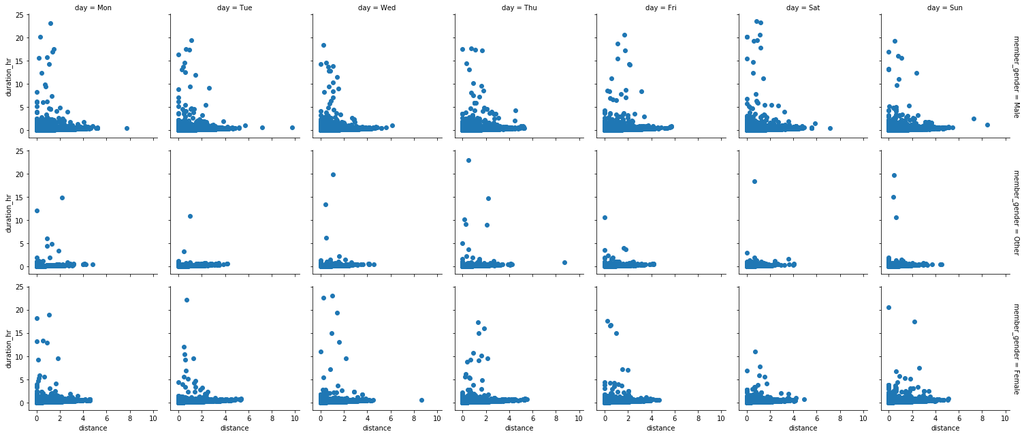